# Clusterized Hong Kong Daily Passenger Flows Report via MSTL & SARIMAX methods

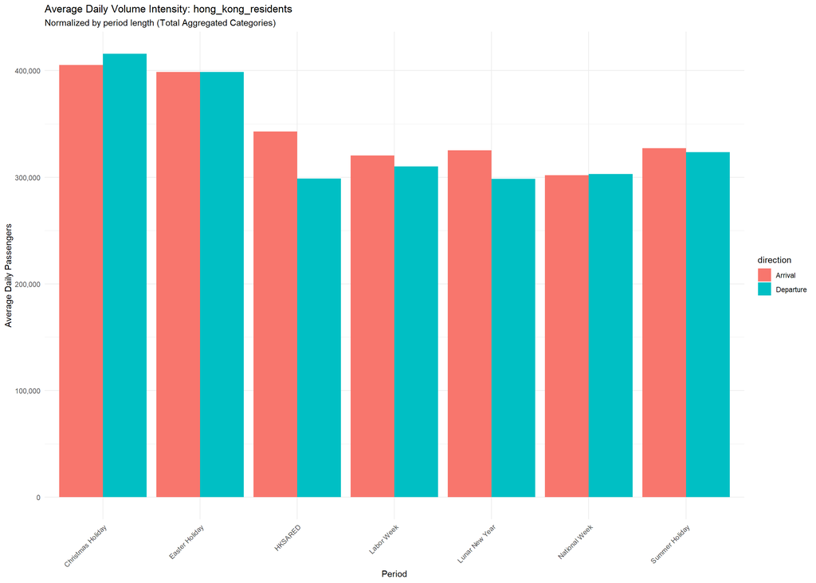

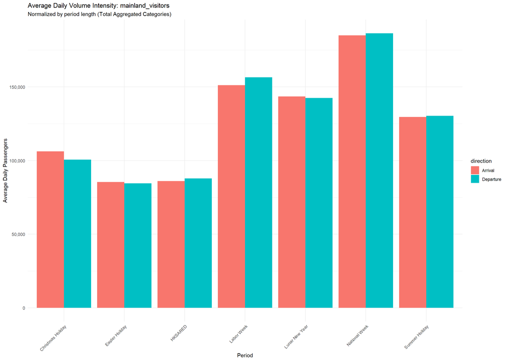

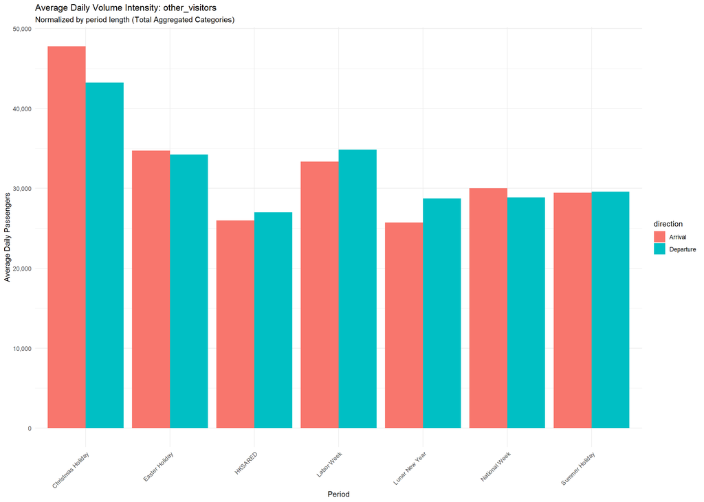

```r
# ========================================================================
# PHASE 2: NORMALIZED SUMMARY HISTOGRAMS (Daily Average)
# ========================================================================
v_types <- unique(summary_stats$visitor_type)

for (v in v_types) {
  plot_data <- summary_stats %>% filter(visitor_type == v)

  p <- ggplot(plot_data, aes(x = Period, y = Daily_Avg, fill = direction)) +
    geom_bar(stat = "identity", position = "dodge") +
    labs(
      title = paste("Average Daily Volume Intensity:", v),
      subtitle = "Normalized by period length (Total Aggregated Categories)",
      x = "Period", y = "Average Daily Passengers"
    ) +
    theme_minimal() +
    theme(axis.text.x = element_text(angle = 45, hjust = 1)) +
    scale_y_continuous(labels = comma)

  print(p)
}
```

### More detail about Holiday

Comparing Arrival and Departure, we can see the peak days in Arrival are later than Departure peak days by around 3–5 days, or at most 7–8 days. Moreover, the right tail of Arrival is usually longer than Departure, as most people tend to travel at the beginning of the holiday but with different lengths of travel, in between 3-day short-travel or 7-day long-travel. Some possible reasons, like preference of travel days, holiday lengths, crossing weekends or not, etc., will affect the pattern of Arrival as well.

For the summary plots of holidays, some trivial patterns are found:

For Hong Kong residents, the top 3 traveling periods of holidays are Christmas, Easter, and Summer, with >400,000, 400,000, and 330,000 daily on average. Meanwhile, it is also found that HKSARED, Labor Week, and Lunar New Year attract more Hong Kong residents back than leave, with 10,000 to 40,000 more when comparing the average daily Arrival and Departure numbers.

For mainland visitors, the top 3 traveling periods of holidays are National Week, Labor Week, and Lunar New Year, with 180,000, 150,000, and 140,000 daily on average. And the Arrival and Departure numbers are more or less the same among all periods of holidays.

For overseas visitors, the top 3 traveling periods of holidays are Christmas, Easter, and Labor Week, with 45,000 and 35,000 daily on average. Interestingly, they come more than leave within 7 days of the Christmas holiday, possibly because a long-travel trip of more than 7 days is out of the extraction period.

## Part 3: Residual Diagnostics & Performance Matrix Evaluation

To evaluate model accuracy, we compute the Root Mean Squared Error (RMSE), the Coefficient of Determination ($R^2$), and the non-parametric continuous Kullback-Leibler Divergence ($D_{\text{KL}}$) via Gaussian Kernel Density Estimation.

```
##
## ### Framework Symmetrical Evaluation Matrix Dashboard:  Main | Arrival | hong_kong_residents
```

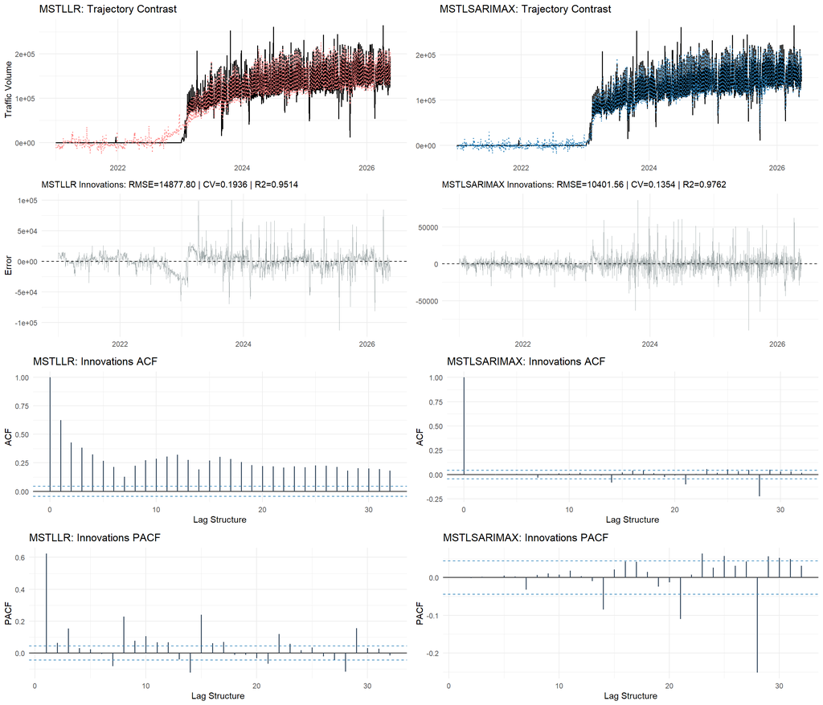

```
##
## ### Framework Symmetrical Evaluation Matrix Dashboard:  Sub | Arrival | hong_kong_residents
```

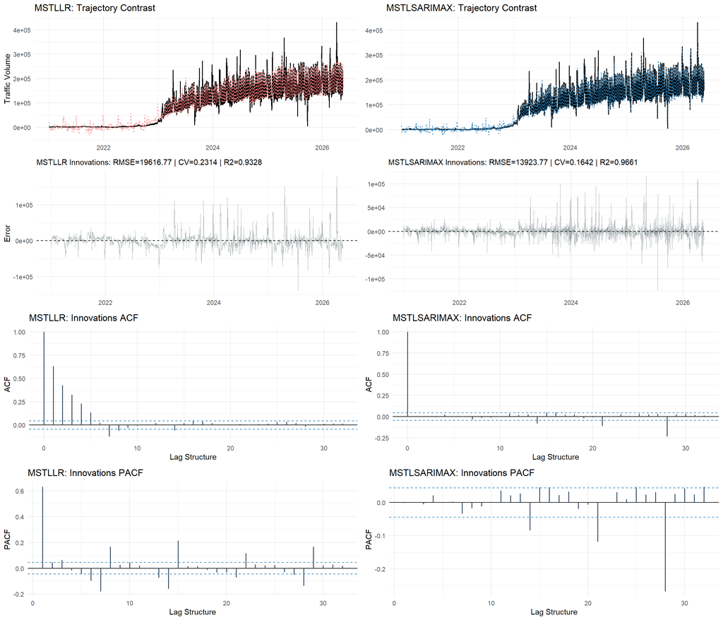

```
##
## ### Framework Symmetrical Evaluation Matrix Dashboard:  Main | Departure | hong_kong_residents
```

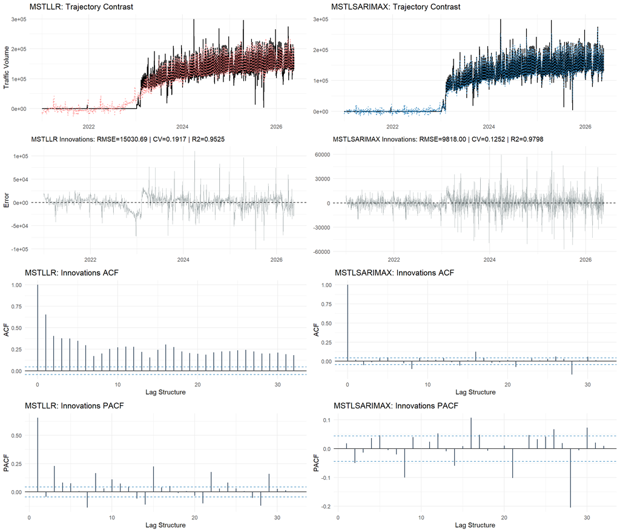

```
##
## ### Framework Symmetrical Evaluation Matrix Dashboard:  Sub | Departure | hong_kong_residents
```

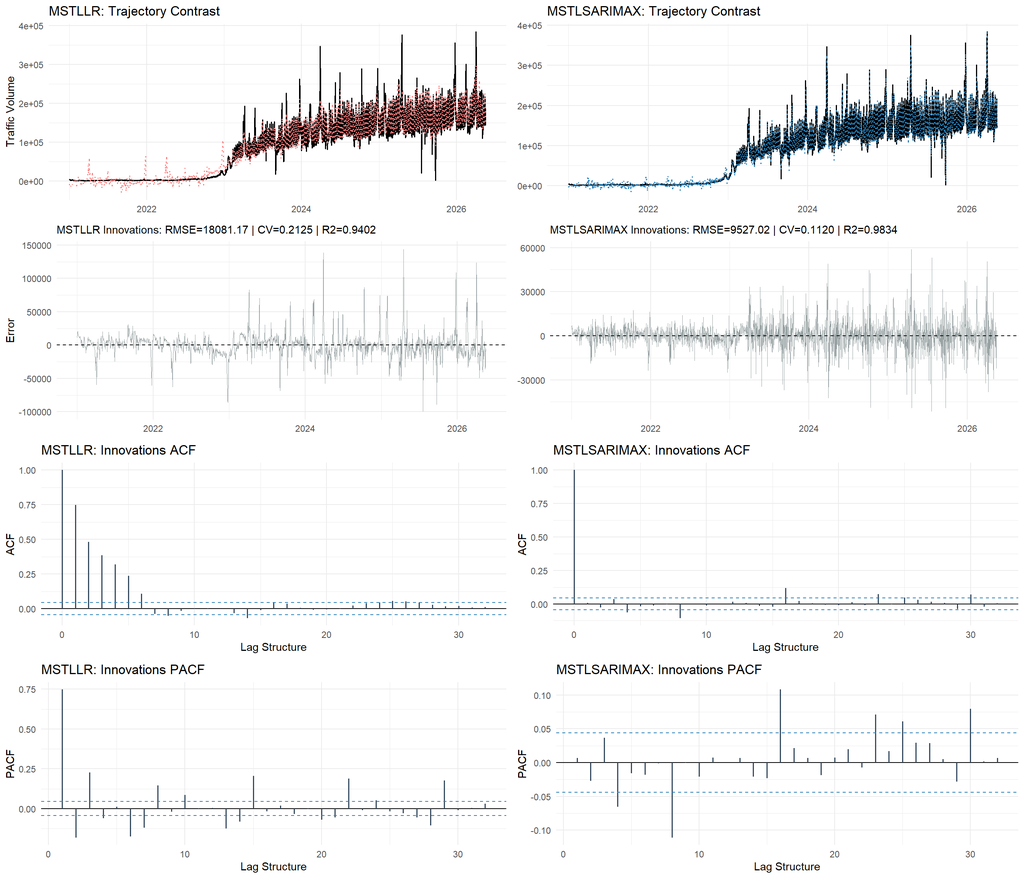

```
##
## ### Framework Symmetrical Evaluation Matrix Dashboard:  Main | Arrival | mainland_visitors
```

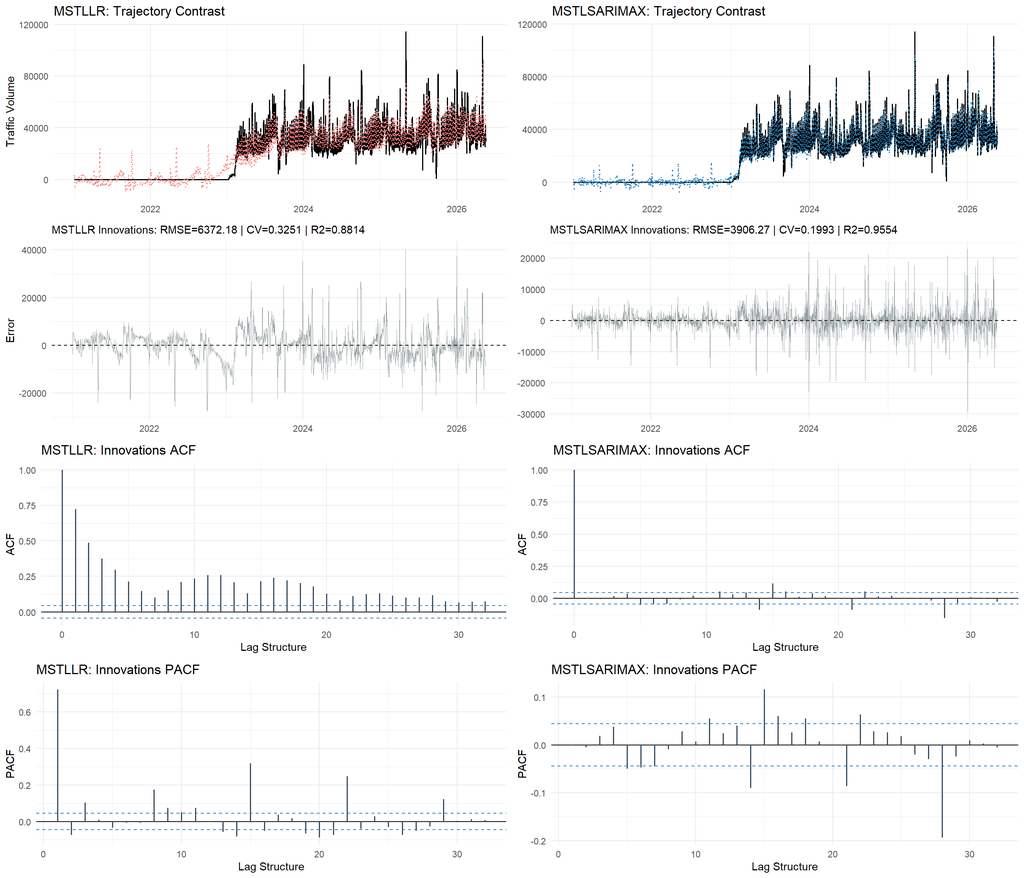

```
##
## ### Framework Symmetrical Evaluation Matrix Dashboard:  Sub | Arrival | mainland_visitors
```

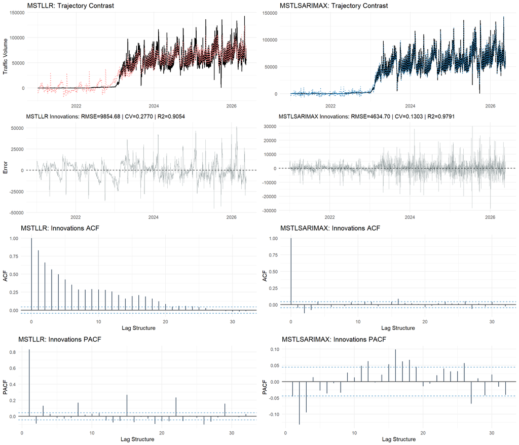

```
##
## ### Framework Symmetrical Evaluation Matrix Dashboard:  Main | Departure | mainland_visitors
```

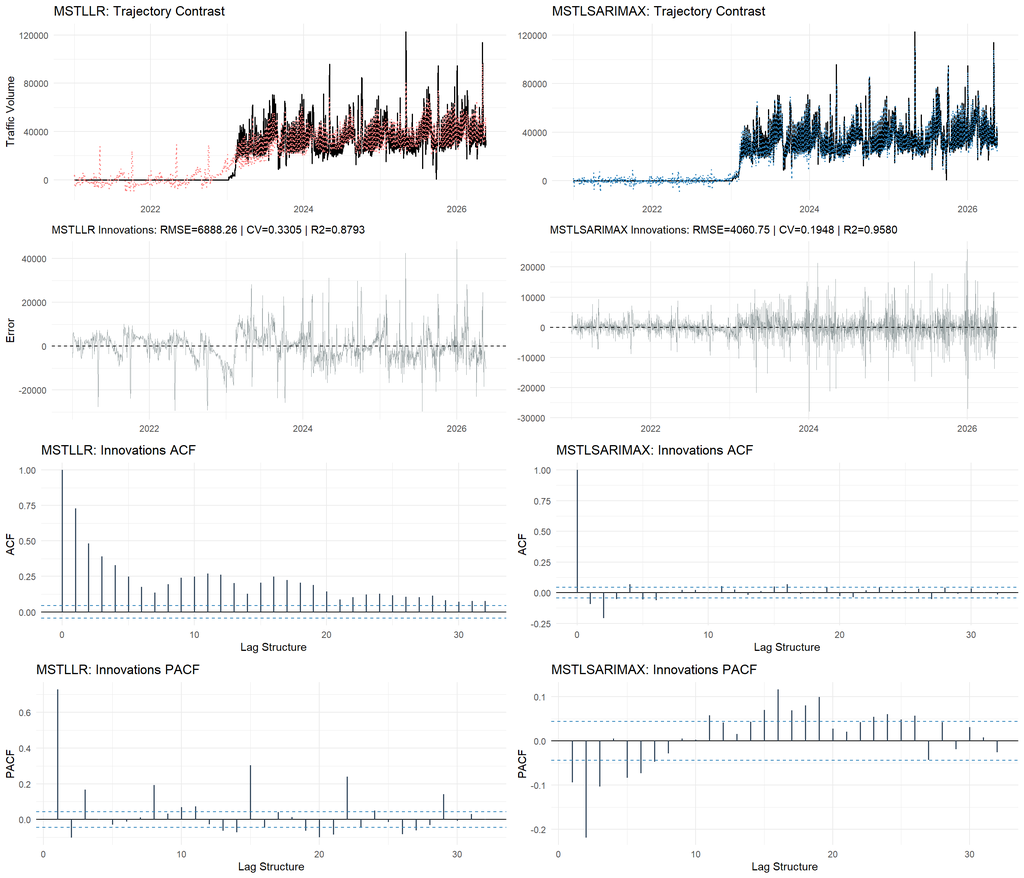

```
##
## ### Framework Symmetrical Evaluation Matrix Dashboard:  Sub | Departure | mainland_visitors
```

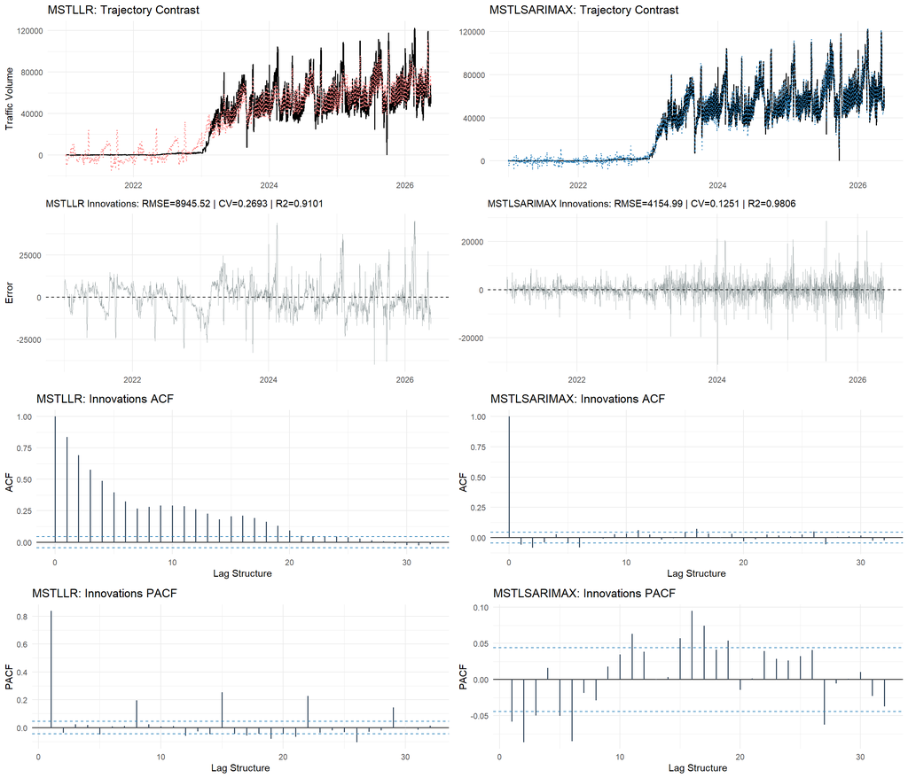

```
##
## ### Framework Symmetrical Evaluation Matrix Dashboard:  Main | Arrival | other_visitors
```

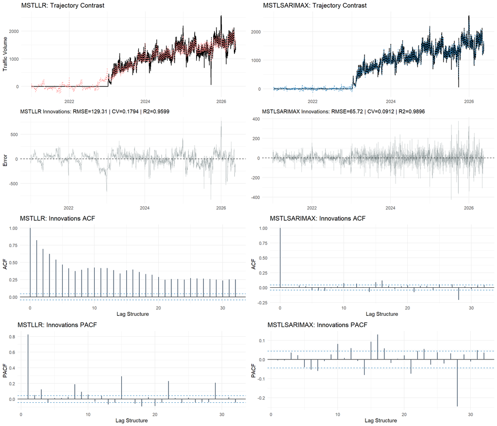

```
##
## ### Framework Symmetrical Evaluation Matrix Dashboard:  Sub | Arrival | other_visitors
```

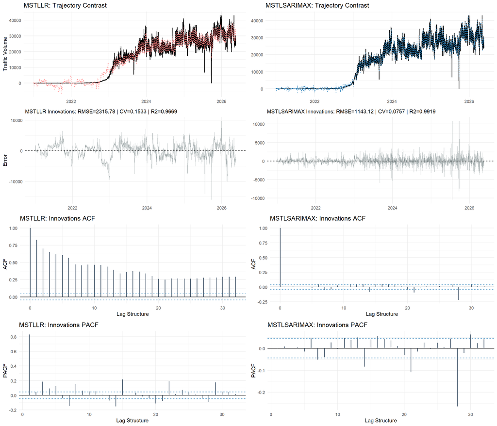

```
##
## ### Framework Symmetrical Evaluation Matrix Dashboard:  Main | Departure | other_visitors
```

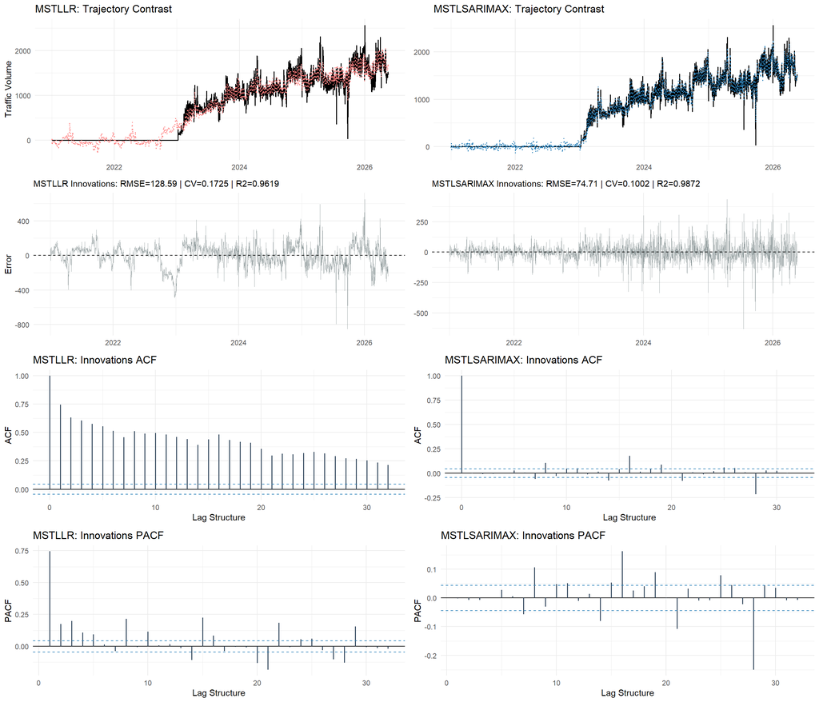

```
##
## ### Framework Symmetrical Evaluation Matrix Dashboard:  Sub | Departure | other_visitors
```

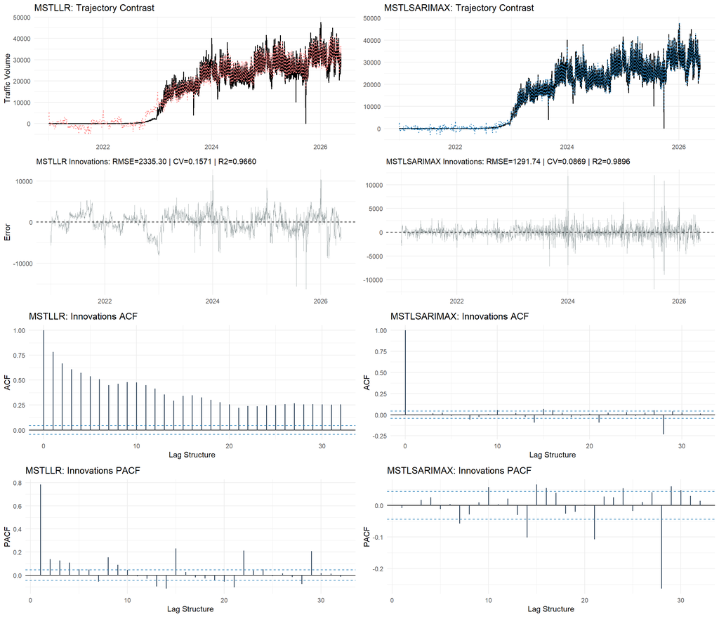

```r
# ========================================================================
# ADVANCED RESIDUAL DIAGNOSTICS LAYER
# ========================================================================

compute_kl_divergence <- function(actual, fitted) {
  actual <- actual[!is.na(actual)]
  fitted <- fitted[!is.na(fitted)]

  combined <- c(actual, fitted)
  sd_val   <- sd(combined)
  if (is.na(sd_val) || sd_val == 0) return(ifelse(all(actual == fitted), 0, Inf))

  lower_bound <- min(combined) - 2 * sd_val
  upper_bound <- max(combined) + 2 * sd_val

  p_kde <- tryCatch(density(actual, from = lower_bound, to = upper_bound, n = length(actual)), error = function(e) NULL)
  q_kde <- tryCatch(density(fitted, from = lower_bound, to = upper_bound, n = length(fitted)), error = function(e) NULL)

  if (is.null(p_kde) || is.null(q_kde)) {
    # Fallback to discrete approximation if continuous density evaluation fails
    breaks   <- seq(lower_bound, upper_bound, length.out = 513)
    p_counts <- hist(actual, breaks = breaks, plot = FALSE)$counts
    q_counts <- hist(fitted, breaks = breaks, plot = FALSE)$counts
    p_pdf    <- p_counts / sum(p_counts)
    q_pdf    <- q_counts / sum(q_counts)
  } else {
    p_pdf    <- p_kde$y / sum(p_kde$y)
    q_pdf    <- q_kde$y / sum(q_kde$y)
  }

  eps   <- 1e-12
  p_pdf <- (p_pdf + eps) / sum(p_pdf + eps)
  q_pdf <- (q_pdf + eps) / sum(q_pdf + eps)

  return(sum(p_pdf * log(p_pdf / q_pdf)))
}

gg_acf <- function(res, title = "Residual ACF Profile") {
  if (all(res == 0, na.rm = TRUE) || var(res, na.rm = TRUE) == 0) {
    return(ggplot() + labs(title = paste(title, "(Zero Residual Variance)")) + theme_minimal())
  }
  acf_out <- acf(res, plot = FALSE, na.action = na.pass)
  df <- data.frame(Lag = as.vector(acf_out$lag), ACF = as.vector(acf_out$acf))
  ci <- qnorm((1 + 0.95) / 2) / sqrt(sum(!is.na(res)))
  ggplot(df, aes(x = Lag, y = ACF)) +
    geom_hline(yintercept = 0, color = "black") +
    geom_segment(aes(xend = Lag, yend = 0), color = "#34495e", size = 0.6) +
    geom_hline(yintercept = c(-ci, ci), color = "#2980b9", linetype = "dashed") +
    labs(title = title, x = "Lag Structure", y = "ACF") + theme_minimal()
}

gg_pacf <- function(res, title = "Residual PACF Profile") {
  if (all(res == 0, na.rm = TRUE) || var(res, na.rm = TRUE) == 0) {
    return(ggplot() + labs(title = paste(title, "(Zero Residual Variance)")) + theme_minimal())
  }
  pacf_out <- pacf(res, plot = FALSE, na.action = na.pass)
  df <- data.frame(Lag = as.vector(pacf_out$lag), PACF = as.vector(pacf_out$acf))
  ci <- qnorm((1 + 0.95) / 2) / sqrt(sum(!is.na(res)))
  ggplot(df, aes(x = Lag, y = PACF)) +
    geom_hline(yintercept = 0, color = "black") +
    geom_segment(aes(xend = Lag, yend = 0), color = "#34495e", size = 0.6) +
    geom_hline(yintercept = c(-ci, ci), color = "#2980b9", linetype = "dashed") +
    labs(title = title, x = "Lag Structure", y = "PACF") + theme_minimal()
}


# ========================================================================
# RESIDUAL DIAGNOSTICS LAYER
# ========================================================================

for (label in names(residual_diagnostic_log)) {
  model_set <- residual_diagnostic_log[[label]]
  n_obs     <- length(model_set$actual)

  # Structural alignment validation safeguard
  if (length(model_set$fitted_lr) != n_obs || length(model_set$fitted_arima) != n_obs) {
    message(sprintf("Skipping diagnostics for %s: Array dimensions mismatched.", label))
    next
  }

  # Algebraic checks against zero variance denominators
  denom_total <- sum((model_set$actual - mean(model_set$actual, na.rm=TRUE))^2, na.rm=TRUE)
  actual_mean <- mean(model_set$actual, na.rm=TRUE)

  # 1. Metrics: LR Layer
  rmse_lr <- sqrt(mean(model_set$residuals_lr^2, na.rm = TRUE))
  cv_lr   <- if(actual_mean != 0) sd(model_set$residuals_lr, na.rm = TRUE) / actual_mean else 0
  r2_lr   <- if(denom_total > 0) 1 - (sum(model_set$residuals_lr^2, na.rm=TRUE) / denom_total) else 1
  kl_lr   <- compute_kl_divergence(model_set$actual, model_set$fitted_lr)

  # 2. Metrics: ARIMA Layer
  rmse_arima <- sqrt(mean(model_set$residuals_arima^2, na.rm = TRUE))
  cv_arima   <- if(actual_mean != 0) sd(model_set$residuals_arima, na.rm = TRUE) / actual_mean else 0
  r2_arima   <- if(denom_total > 0) 1 - (sum(model_set$residuals_arima^2, na.rm=TRUE) / denom_total) else 1
  kl_arima   <- compute_kl_divergence(model_set$actual, model_set$fitted_arima)

  # Update Performance Log
  performance_metrics_log[[label]] <- data.frame(
    Category                   = toupper(model_set$metadata$cat),
    Direction                  = toupper(model_set$metadata$ad),
    Visitor_Type               = model_set$metadata$v_type,
    `RMSE (MSTLLR)`            = rmse_lr,
    `RMSE (MSTLSARIMAX)`        = rmse_arima,
    `CV (MSTLLR)`              = cv_lr,
    `CV (MSTLSARIMAX)`          = cv_arima,
    `R^2 (MSTLLR)`             = r2_lr,
    `R^2 (MSTLSARIMAX)`         = r2_arima,
    `KL_Divergence (MSTLLR)`   = kl_lr,
    `KL_Divergence (MSTLSARIMAX)` = kl_arima,
    check.names                = FALSE
  )

  # Trajectory Plotting
  gg_df <- data.frame(
    Date             = model_set$date,
    Actual           = model_set$actual,
    Fitted_LR        = model_set$fitted_lr,
    Residual_LR      = model_set$residuals_lr,
    Fitted_Arima     = model_set$fitted_arima,
    Residual_Arima   = model_set$residuals_arima
  )

  p_traj_lr <- ggplot(gg_df, aes(x = Date)) +
    geom_line(aes(y = Actual, color = "Actual Stream"), size = 0.55) +
    geom_line(aes(y = Fitted_LR, color = "Fit Estimate"), linetype = "dotted", size = 0.6) +
    scale_color_manual(values = c("Actual Stream" = "black", "Fit Estimate" = "#ff7f7f")) +
    labs(title = "MSTLLR: Trajectory Contrast", y = "Traffic Volume", x = NULL) +
    theme_minimal() + theme(legend.position = "none")

  p_res_lr <- ggplot(gg_df, aes(x = Date, y = Residual_LR)) +
    geom_line(color = "#7f8c8d", size = 0.35, alpha = 0.8) +
    geom_hline(yintercept = 0, color = "black", linetype = "dashed", size = 0.4) +
    labs(subtitle = sprintf("MSTLLR Innovations: RMSE=%.2f | CV=%.4f | R2=%.4f", rmse_lr, cv_lr, r2_lr), y = "Error", x = NULL) +
    theme_minimal()

  p_acf_lr  <- gg_acf(model_set$residuals_lr, title = "MSTLLR: Innovations ACF")
  p_pacf_lr <- gg_pacf(model_set$residuals_lr, title = "MSTLLR: Innovations PACF")

  p_traj_arima <- ggplot(gg_df, aes(x = Date)) +
    geom_line(aes(y = Actual, color = "Actual Stream"), size = 0.55) +
    geom_line(aes(y = Fitted_Arima, color = "Fit Estimate"), linetype = "dotted", size = 0.6) +
    scale_color_manual(values = c("Actual Stream" = "black", "Fit Estimate" = "#2980b9")) +
    labs(title = "MSTLSARIMAX: Trajectory Contrast", y = NULL, x = NULL) +
    theme_minimal() + theme(legend.position = "none")

  p_res_arima <- ggplot(gg_df, aes(x = Date, y = Residual_Arima)) +
    geom_line(color = "#7f8c8d", size = 0.35, alpha = 0.8) +
    geom_hline(yintercept = 0, color = "black", linetype = "dashed", size = 0.4) +
    labs(subtitle = sprintf("MSTLSARIMAX Innovations: RMSE=%.2f | CV=%.4f | R2=%.4f", rmse_arima, cv_arima, r2_arima), y = NULL, x = NULL) +
    theme_minimal()

  p_acf_arima  <- gg_acf(model_set$residuals_arima, title = "MSTLSARIMAX: Innovations ACF")
  p_pacf_arima <- gg_pacf(model_set$residuals_arima, title = "MSTLSARIMAX: Innovations PACF")

  cat("\n### Framework Symmetrical Evaluation Matrix Dashboard: ", label, "\n")
  invisible(grid.arrange(
    p_traj_lr,   p_traj_arima,
    p_res_lr,    p_res_arima,
    p_acf_lr,    p_acf_arima,
    p_pacf_lr,   p_pacf_arima,
    ncol = 2
  ))
}
```

### Framework Consolidated Performance Summary

The comprehensive table below provides a full diagnostic overview of 2 mixture model frameworks across categories of control points and 3 types of passengers, for 4 measurements.

```r
# Automatically renders as paired column blocks per performance metric type
master_metrics_table <- bind_rows(performance_metrics_log)

knitr::kable(master_metrics_table, digits = 4, format = "markdown",
            caption = "Consolidated Comparative Strategic Performance Matrix (MSTLLR Left vs. MSTLSARIMAX Right Columns)")
```

Consolidated Comparative Strategic Performance Matrix (MSTLLR Left vs. MSTLSARIMAX Right Columns)

| Category | Direction | Visitor_Type | RMSE (MSTLLR) | RMSE (MSTLSARIMAX) | CV (MSTLLR) | CV (MSTLSARIMAX) | R^2 (MSTLLR) | R^2 (MSTLSARIMAX) | KL_Divergence (MSTLLR) | KL_Divergence (MSTLSARIMAX) |
| --- | --- | --- | --- | --- | --- | --- | --- | --- | --- | --- |
| MAIN | ARRIVAL | hong_kong_residents | 14877.8041 | 10401.5635 | 0.1936 | 0.1354 | 0.9514 | 0.9762 | 0.0381 | 0.0127 |
| SUB | ARRIVAL | hong_kong_residents | 19616.7707 | 13923.7691 | 0.2314 | 0.1642 | 0.9328 | 0.9661 | 0.0422 | 0.0162 |
| MAIN | DEPARTURE | hong_kong_residents | 15030.6894 | 9818.0038 | 0.1917 | 0.1252 | 0.9525 | 0.9798 | 0.0447 | 0.0059 |
| SUB | DEPARTURE | hong_kong_residents | 18081.1699 | 9527.0248 | 0.2125 | 0.1120 | 0.9402 | 0.9834 | 0.0512 | 0.0026 |
| MAIN | ARRIVAL | mainland_visitors | 6372.1836 | 3906.2670 | 0.3251 | 0.1993 | 0.8814 | 0.9554 | 0.0908 | 0.0152 |
| SUB | ARRIVAL | mainland_visitors | 9854.6782 | 4634.6987 | 0.2770 | 0.1303 | 0.9054 | 0.9791 | 0.0966 | 0.0034 |
| MAIN | DEPARTURE | mainland_visitors | 6888.2567 | 4060.7525 | 0.3305 | 0.1948 | 0.8793 | 0.9580 | 0.0852 | 0.0112 |
| SUB | DEPARTURE | mainland_visitors | 8945.5244 | 4154.9897 | 0.2693 | 0.1251 | 0.9101 | 0.9806 | 0.0972 | 0.0028 |
| MAIN | ARRIVAL | other_visitors | 129.3068 | 65.7221 | 0.1794 | 0.0912 | 0.9599 | 0.9896 | 0.0460 | 0.0021 |
| SUB | ARRIVAL | other_visitors | 2315.7786 | 1143.1176 | 0.1533 | 0.0757 | 0.9669 | 0.9919 | 0.0384 | 0.0011 |
| MAIN | DEPARTURE | other_visitors | 128.5907 | 74.7053 | 0.1725 | 0.1002 | 0.9619 | 0.9872 | 0.0454 | 0.0029 |
| SUB | DEPARTURE | other_visitors | 2335.2963 | 1291.7394 | 0.1571 | 0.0869 | 0.9660 | 0.9896 | 0.0319 | 0.0012 |

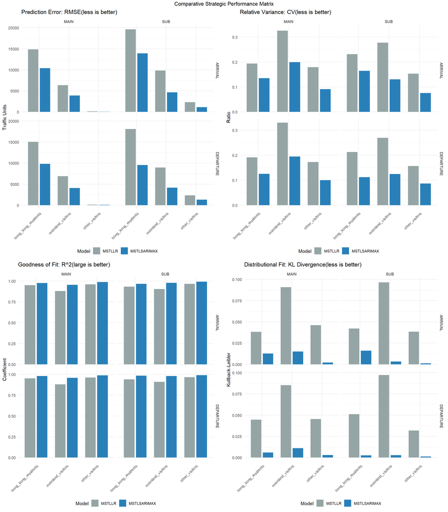

```r
library(ggplot2)
library(tidyr)
library(dplyr)
library(gridExtra)

# 1. Aggregate and Tidy Data
# Extracting performance metrics from the log list
metrics_df <- do.call(rbind, performance_metrics_log)

# Reshaping to long format for faceted plotting
# We identify the metric and the model type (LR vs SARIMAX)
tidy_metrics <- metrics_df %>%
  pivot_longer(
    cols = -c(Category, Direction, Visitor_Type),
    names_to = "Metric_Model",
    values_to = "Value"
  ) %>%
  separate(Metric_Model, into = c("Metric", "Model"), sep = " \\(") %>%
  mutate(Model = gsub("\\)", "", Model))

# Ensure factors for consistent plotting
tidy_metrics$Metric <- factor(tidy_metrics$Metric,
                              levels = c("RMSE", "CV", "R^2", "KL_Divergence"))
tidy_metrics$Model  <- factor(tidy_metrics$Model,
                              levels = c("MSTLLR", "MSTLSARIMAX"))

# 2. Visualization Function
# We create a function to generate grouped bar charts
plot_metric <- function(metric_name, title, ylabel) {
  df_subset <- tidy_metrics %>% filter(Metric == metric_name)

  ggplot(df_subset, aes(x = Visitor_Type, y = Value, fill = Model)) +
    geom_bar(stat = "identity", position = position_dodge(width = 0.8), width = 0.7) +
    facet_grid(Direction ~ Category) +
    scale_fill_manual(values = c("MSTLLR" = "#95a5a6", "MSTLSARIMAX" = "#2980b9")) +
    labs(title = title, y = ylabel, x = NULL) +
    theme_minimal() +
    theme(axis.text.x = element_text(angle = 45, hjust = 1),
          legend.position = "bottom")
}

# 3. Generate 4-Panel Dashboard
p1 <- plot_metric("RMSE", "Prediction Error: RMSE(less is better)", "Traffic Units")
p2 <- plot_metric("CV", "Relative Variance: CV(less is better)", "Ratio")
p3 <- plot_metric("R^2", "Goodness of Fit: R^2(large is better)", "Coefficient")
p4 <- plot_metric("KL_Divergence", "Distributional Fit: KL Divergence(less is better)", "Kullback-Leibler")

# Combine into a single dashboard
invisible(grid.arrange(p1, p2, p3, p4, ncol = 2, top = "Comparative Strategic Performance Matrix"))
```

### Residue analysis

We can see that all models across Arrival/Departure for the 3 types of passengers have good performance across the 4 measurements. For MSTLLR, all models have sufficiently good $R^2$ values above 85%, CV% less than 40, and KL-Div less than 0.1. However, the ACF and PACF of the residuals report that some significant autocorrelation signals are not eliminated. This somewhat matches our intuition that traffic numbers are correlated within a week, so we consider a time series model to handle the residuals.

## Part 4: Predictive Simulation (Over whole 2026)

We further predict the 2026 passenger traffic, using the fitted model, for the cluster groups “Main,” “Sub,” and “Low” first. Then, to make the predictions more meaningful, we reverse the merging process from the cluster groups back to the control points, using a weighted average method in short (More details in coming subsection). After the reversible transformation, we now able to predict the daily passenger in control points.

#### Details of the Aggregation/Disaggregation Logic

Given that the transformation $f: \text{Clusters} \to \text{Nodes}$ is a linear mapping of the form $\hat{Y}_{i,v} = \sum_{c \in C} w_{i,c} \hat{Y}_{c,v}$, where $\sum w_{i,c} = 1$, the variance of the forecast error at the control point level is bounded by the variance of the forecast error at the cluster level. This ensures that the fidelity of the seasonal components ($S_t^{(365)}$) and cyclical variations ($S_t^{(7)}$) is maintained across the hierarchy.

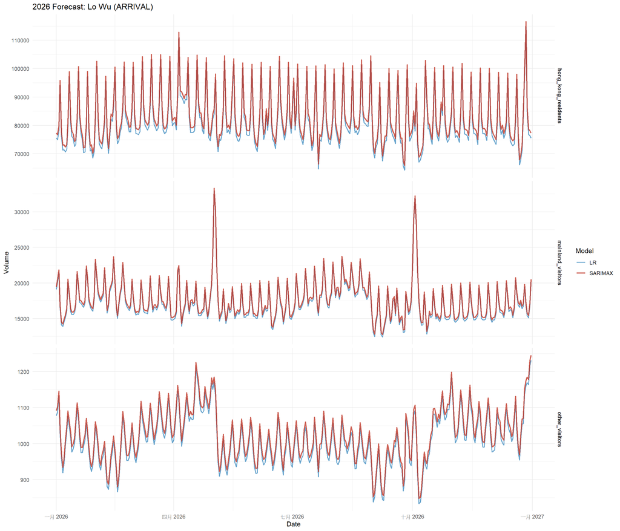

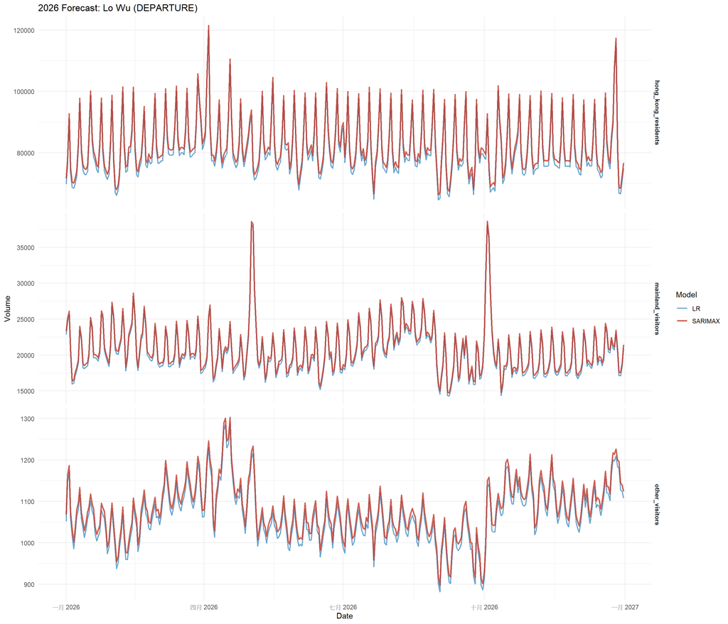

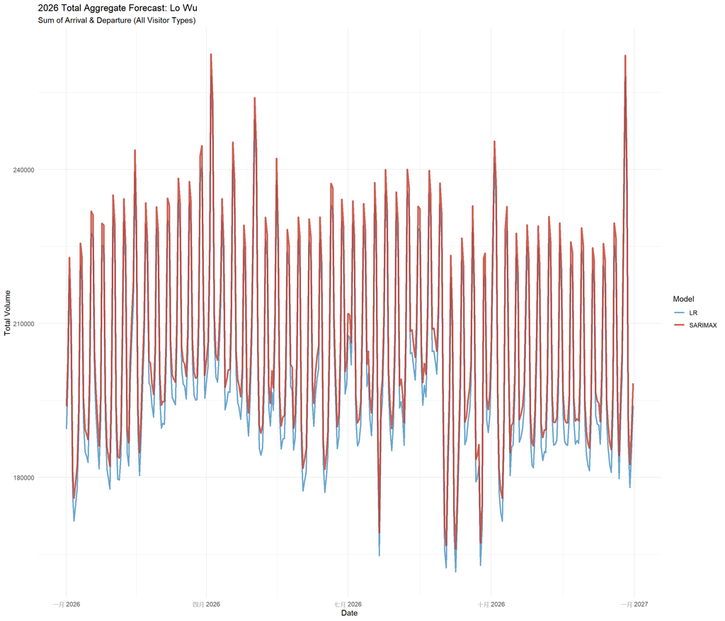

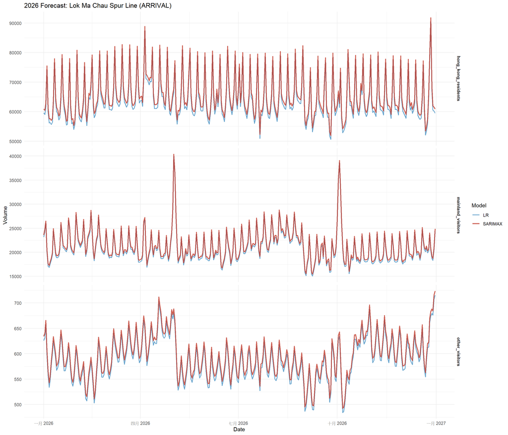

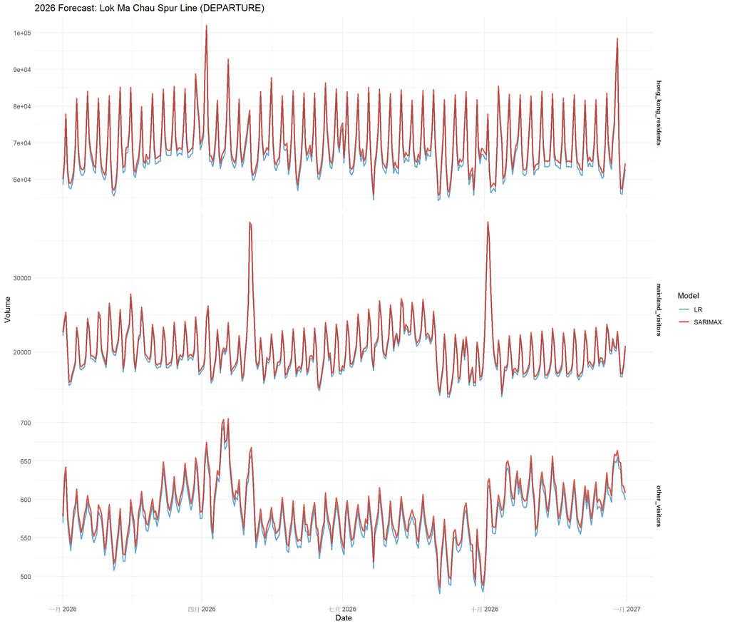

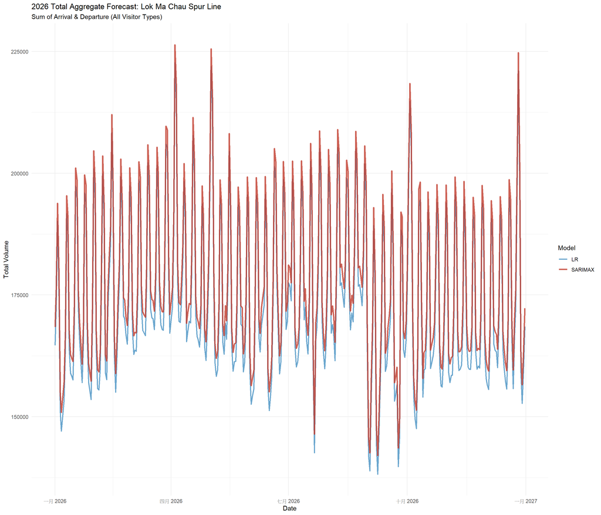

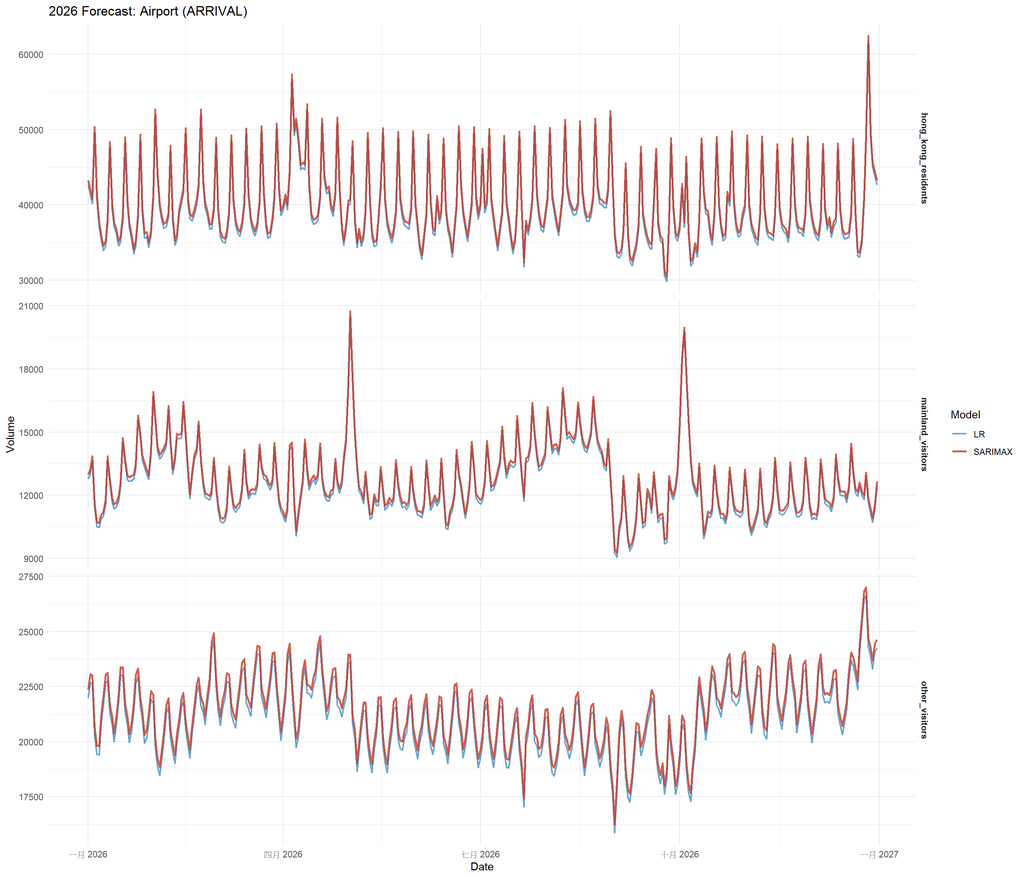

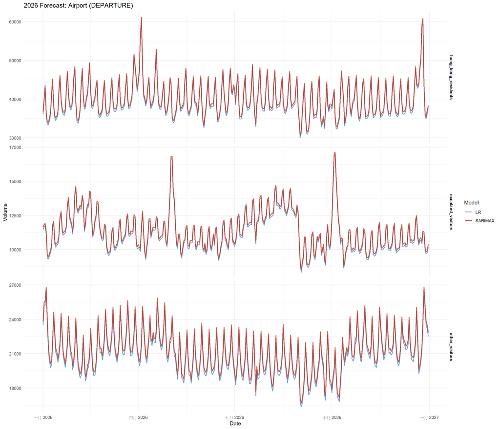

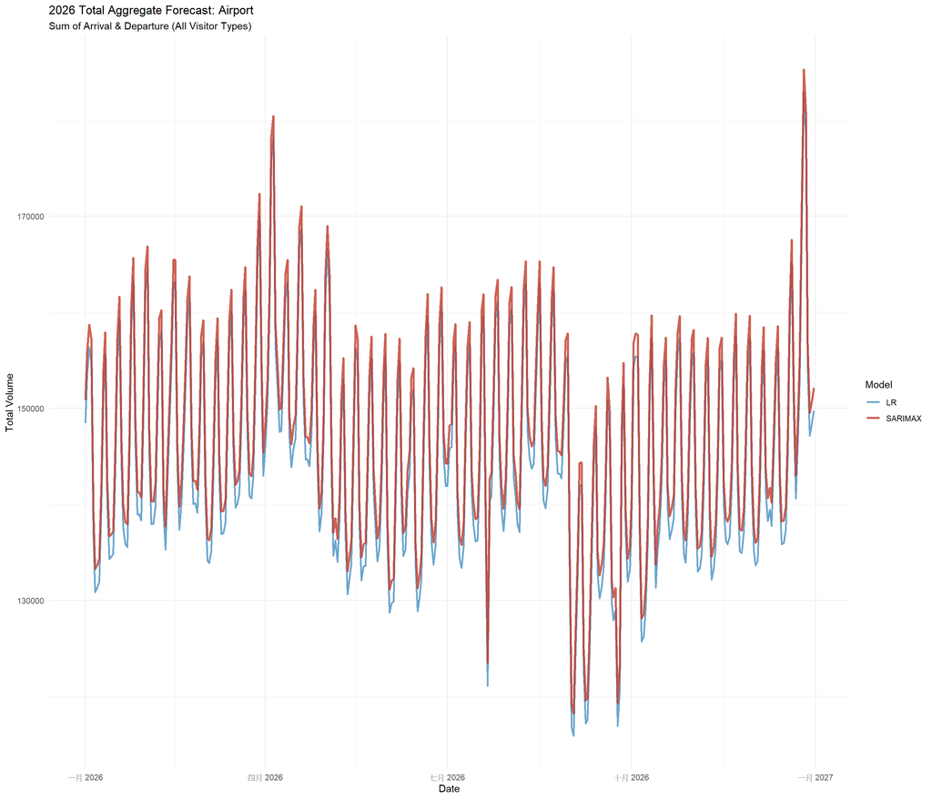

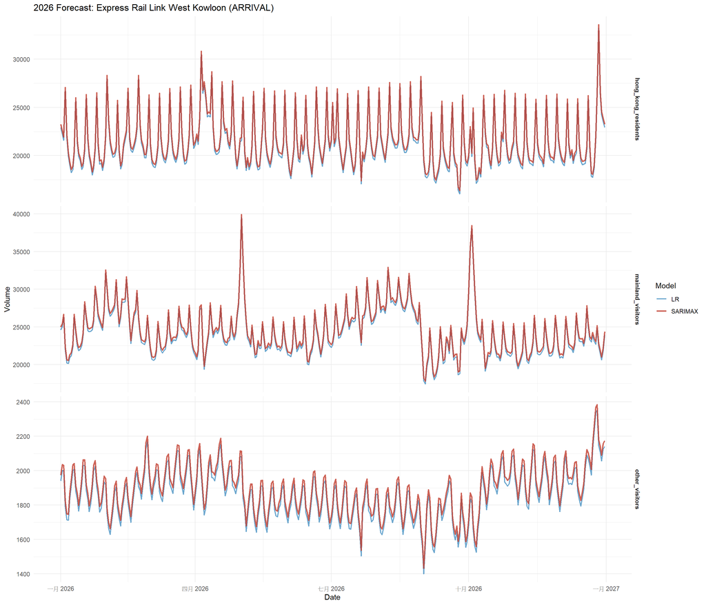

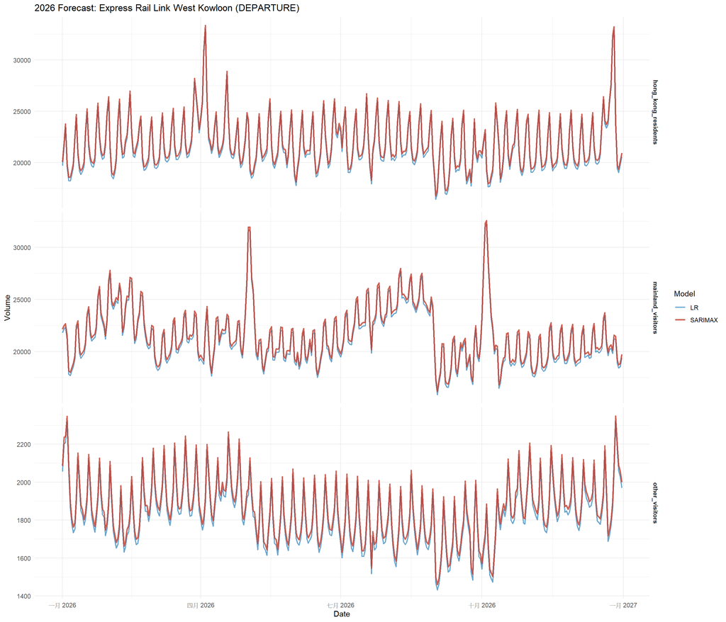

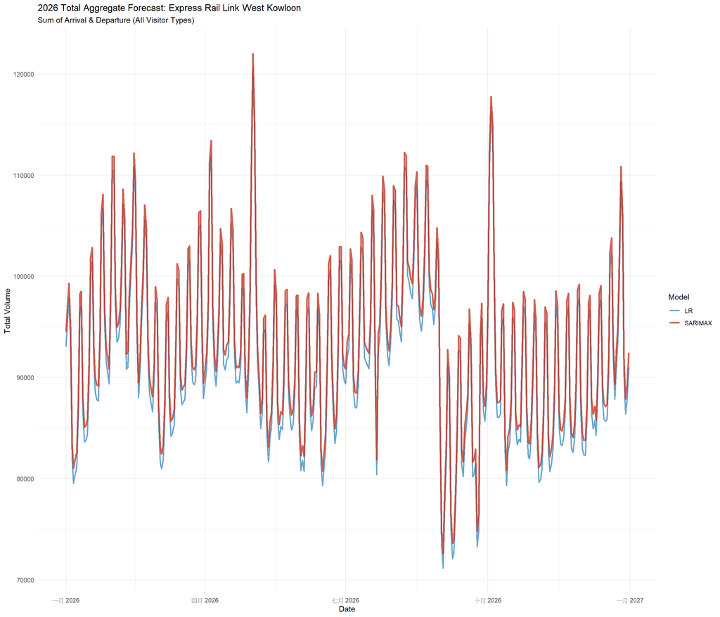

[9 more figures not shown]

```r
library(forecast)
library(ggplot2)
library(dplyr)
library(tidyr)

# [Standard Setup]
if (!file.exists("models_backup.rds")) stop("Error: models_backup.rds not found.")
model_store <- readRDS("models_backup.rds")

unique_cps     <- unique(cp_weights$control_point)
directions     <- c("Arrival", "Departure")
visitor_types  <- c("hong_kong_residents", "mainland_visitors", "other_visitors")
model_keys     <- names(model_store)
target_dates   <- seq(as.Date("2026-01-01"), as.Date("2026-12-31"), by = "day")
h              <- length(target_dates)

all_cps_data_store <- list()

# --- Main Loop ---
for (cp in unique_cps) {

  # This list will store dataframes for Arrival and Departure to be used later for the Total plot
  cp_all_data <- list()
  for (dir in directions) {

    cat_match <- cp_weights %>%
      filter(control_point == cp, arrival_departure == dir) %>%
      pull(category) %>% unique()

    if(length(cat_match) == 0) next

    plot_data_list <- list()

    for (v_type in visitor_types) {
      model_key <- paste(cat_match, dir, v_type, sep = " | ")
      if (!model_key %in% model_keys) next

      m <- model_store[[model_key]]

      # [Prediction Logic]
      future_df <- data.frame(
        date = target_dates,
        weekday = factor(weekdays(target_dates), levels = m$lm$xlevels$weekday),
        doy = as.numeric(format(target_dates, "%j")),
        policy_factor = factor(tail(m$lm$xlevels$policy_factor, 1), levels = m$lm$xlevels$policy_factor)
      )

      future_df$s7   <- as.numeric(m$w_map[as.character(future_df$weekday)])
      future_df$s365 <- as.numeric(m$doy_map[as.character(future_df$doy)])
      future_df$s365[is.na(future_df$s365)] <- 0

      r2_fc_arima <- if(!is.null(m$sSARIMAX)) as.numeric(forecast(m$sSARIMAX, h = h)$mean) else 0
      r2_fc_lr    <- as.numeric(predict(m$lm, newdata = future_df))
      trend_val   <- tail(as.numeric(m$mstl[, "Trend"]), 1)
      cp_weight   <- cp_weights %>% filter(control_point == cp, arrival_departure == dir) %>% pull(paste0("weight_", v_type))

      plot_data_list[[v_type]] <- data.frame(
        Date = target_dates,
        SARIMAX = (trend_val + future_df$s7 + future_df$s365 + r2_fc_arima) * cp_weight,
        LR = (trend_val + future_df$s7 + future_df$s365 + r2_fc_lr) * cp_weight,
        visitor_type = v_type,
        direction = dir
      )
    }

    # 1. Render Segmented Plot (For this specific direction)
    if (length(plot_data_list) > 0) {
      combined_df <- bind_rows(plot_data_list)
      cp_all_data[[dir]] <- combined_df # Save for Total calculation

      plot_long <- combined_df %>% pivot_longer(cols = c(SARIMAX, LR), names_to = "Model", values_to = "Volume")

      p <- ggplot(plot_long, aes(x = Date, y = Volume, color = Model, group = Model)) +
        geom_line(aes(size = Model, alpha = Model)) +
        scale_color_manual(values = c("SARIMAX" = "#c0392b", "LR" = "#2980b9")) +
        scale_size_manual(values = c("SARIMAX" = 1.0, "LR" = 0.8)) +
        scale_alpha_manual(values = c("SARIMAX" = 0.8, "LR" = 0.7)) +
        facet_wrap(~ visitor_type, ncol = 1, scales = "free_y", strip.position = "right") +
        labs(title = sprintf("2026 Forecast: %s (%s)", cp, toupper(dir)), y = "Volume", x = "Date") +
        theme_minimal() + theme(strip.text = element_text(face = "bold"))
      print(p)
    }
  }

  # 2. Render Total Aggregate Plot (Arrival + Departure + All Types)
  if (length(cp_all_data) > 0) {
    total_data <- bind_rows(cp_all_data) %>%
      group_by(Date) %>%
      summarise(
        SARIMAX = sum(SARIMAX, na.rm = TRUE),
        LR = sum(LR, na.rm = TRUE),
        .groups = "drop"
      ) %>%
      pivot_longer(cols = c(SARIMAX, LR), names_to = "Model", values_to = "Volume")

    p_total <- ggplot(total_data, aes(x = Date, y = Volume, color = Model, group = Model)) +
      geom_line(aes(size = Model, alpha = Model)) +
      scale_color_manual(values = c("SARIMAX" = "#c0392b", "LR" = "#2980b9")) +
      scale_size_manual(values = c("SARIMAX" = 1.2, "LR" = 1.0)) + # Slightly thicker lines for total
      scale_alpha_manual(values = c("SARIMAX" = 0.8, "LR" = 0.7)) +
      labs(title = sprintf("2026 Total Aggregate Forecast: %s", cp),
           subtitle = "Sum of Arrival & Departure (All Visitor Types)",
           y = "Total Volume", x = "Date") +
      theme_minimal()
    all_cps_data_store[[cp]] <- bind_rows(cp_all_data)
    print(p_total)
  }
}
```

#### Prediction results

The observation that the MSTLSARIMAX model yields higher amplitude predictions for both the mean levels and peak values compared to the MSTLLR approach is theoretically consistent with the underlying structural dynamics of the error term $R_t$.

In the MSTLLR framework, the residual is essentially treated as white noise or modeled through simple deterministic regression components. Conversely, the SARIMAX model explicitly internalizes the autocorrelation structure of the stochastic remainder. During periods of sustained high traffic (e.g., peak festival windows), the positive autocorrelation captured by the AR terms (and potentially reinforced by seasonal MA terms) effectively “boosts” the trajectory, preventing the regression-to-the-mean effect that occurs with standard linear regression. This indicates that the passenger volume is not purely exogenous but maintains a “memory” of recent volume levels, which SARIMAX successfully recovers.

## Insight and application

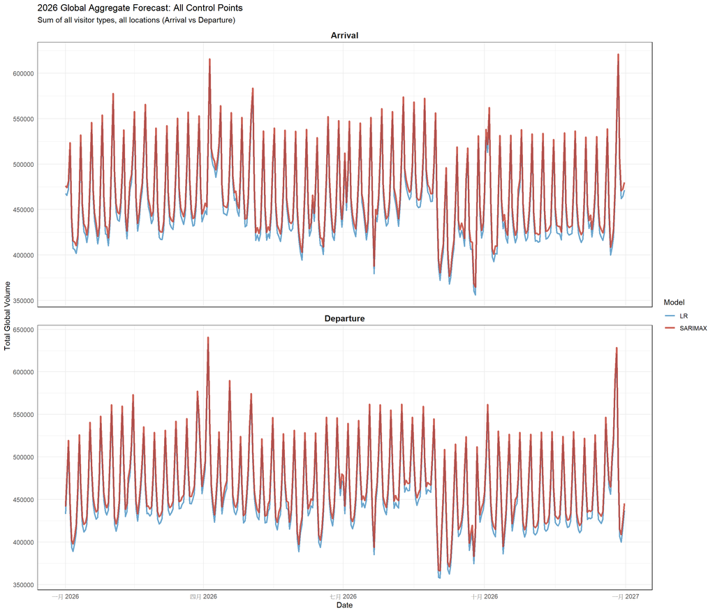

```r
# --- Global Aggregation Logic (Run this AFTER the loop finishes) ---
if (length(all_cps_data_store) > 0) {

  # Combine data from all 17 Control Points
  grand_total_df <- bind_rows(all_cps_data_store) %>%
    group_by(Date, direction) %>%
    summarise(
      SARIMAX = sum(SARIMAX, na.rm = TRUE),
      LR      = sum(LR, na.rm = TRUE),
      .groups = "drop"
    )

  # Pivot for ggplot
  grand_total_long <- grand_total_df %>%
    pivot_longer(cols = c(SARIMAX, LR), names_to = "Model", values_to = "Volume")

  # Visualization
  p_global <- ggplot(grand_total_long, aes(x = Date, y = Volume, color = Model, group = Model)) +
    geom_line(aes(size = Model, alpha = Model)) +
    scale_color_manual(values = c("SARIMAX" = "#c0392b", "LR" = "#2980b9")) +
    scale_size_manual(values = c("SARIMAX" = 1.2, "LR" = 1.0)) +
    scale_alpha_manual(values = c("SARIMAX" = 0.8, "LR" = 0.7)) +
    facet_wrap(~ direction, ncol = 1, scales = "free_y") +
    labs(
      title = "2026 Global Aggregate Forecast: All Control Points",
      subtitle = "Sum of all visitor types, all locations (Arrival vs Departure)",
      y = "Total Global Volume", x = "Date"
    ) +
    theme_minimal() +
    theme(
      strip.text = element_text(face = "bold", size = 12),
      panel.border = element_rect(color = "black", fill = NA)
    )

  print(p_global)
}
```

By aggregating the three passenger cohorts across all control points, we predicted the total daily arrival and departure volumes for Hong Kong. Although some seasonal effects—such as those surrounding Labor Day and National Day—are less pronounced than expected, this model reshapes our understanding of their magnitude. It identifies the Easter holidays in April and the Christmas holidays in December as tourism peaks, while highlighting September as a tourism trough.

These insights may help the Hong Kong Immigration Department manage manpower at each control point more efficiently, enable travel agencies and tourism-related businesses to adjust pricing strategies to attract more tourists and increase profits, and assist MTR management in adjusting East Rail Line train schedules to accommodate peak traffic at the Lo Wu and Lok Ma Chau stations during holiday periods. Finally, we hope this report helps the Hong Kong public gain a more intuitive and quantitative understanding of passenger traffic flows and composition.

## Conclusion

This report uses MSTL decomposition to isolate trend and seasonal components, revealing a sustained growth in tourism for both, coming visitors and outgoing Hong Kong residents. Furthermore, the analysis quantifies the magnitude of peak travel periods—specifically Christmas, the Easter holidays, Labor Week, and National Week—as well as the recurring weekday effect. These insights enable stakeholders to identify peak traffic windows, proactively refine operational policies to manage high tourist volumes, and strategically leverage commercial opportunities to maximize profit.”